# p8105_hw3_jl7033

Joe LaRocca

2024-10-03

## Problem 1

```r
data(ny_noaa)
```

#### Cleaning the Data

```r
ny_noaa_clean = ny_noaa %>%
  janitor::clean_names() %>%
  separate(date, into = c("year", "month", "day"), sep = c(4, 7)) %>%
  mutate(month = str_remove(month, "-"),
         month = month.abb[as.numeric(month)],
         day = str_remove(day, "-"),
         prcp = as.numeric(prcp),
         snow = as.numeric(snow),
         snwd = as.numeric(snwd),
         tmax = as.numeric(tmax),
         tmin = as.numeric(tmin)) %>%
  arrange(desc(year))
```

This dataset contains weather information in New York State between the years 1981 and 2010 (I checked using the `arrange()` function). There are a total of over 2.5 million observations, and the variables measures include the amount of total precipitation, the amount of snowfall, and the maximum and minimum temperatures. About 56.3% of the observations within the dataset have data for maxmimum and minimum temperature, whereas 94.3%, 85.3%, and 77.2% of the observations have data for precipitation, snowfall, and `snwd`, respectively (I found these proportions by dividing the number of rows for which there is data by the total number of rows). For snowfall, the most commonly observed value is 0, since it doesn’t snow during most of the year in New York State.

#### Plot 1: Average Max Temperature in January and July

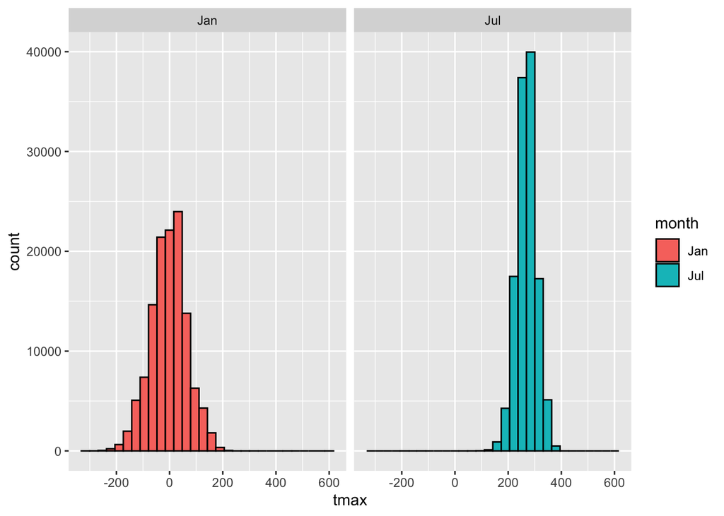

```r
ny_noaa_clean %>%
  filter(month == "Jan" | month == "Jul") %>%
  ggplot(aes(x = tmax, fill = month)) +
  geom_histogram(color = "black") +
  facet_grid(. ~ month)
```

At least to the naked eye, there doesn’t seem to be any significant outliers in either histogram of maximum temperatures; both look to be approximately symmetric, with the January histogram having a slightly greater spread than the July histogram. One question I have is what the tmax values mean, since they don’t seem to align with Fahrenheit, Celsius, or Kelvin.

#### Plot 2: Tmax vs. Tmin for the entire dataset / Snowfall Values

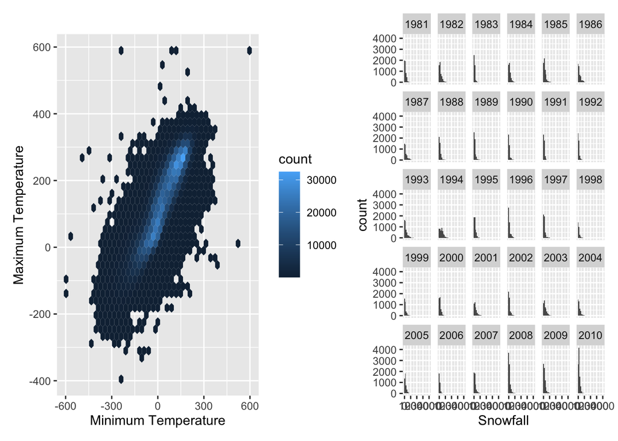

```r
temp_plot = ny_noaa_clean %>%
  ggplot(aes(x = tmin, y = tmax)) +
  geom_hex(bins = 40) +
  labs(
    x = "Minimum Temperature",
    y = "Maximum Temperature"
  )

snow_plot = ny_noaa_clean %>%
  filter(snow > 0, snow < 100) %>%
  ggplot(aes(x = snwd)) +
  geom_histogram() +
  facet_wrap(. ~ year) +
  labs(
    x = "Snowfall"
  )

temp_plot + snow_plot
```

I decided on a hexagonal heat map over a scatterplot due to the size of the dataset, as we were advised to look for alternatives to typical scatterplots with especially large datasets. Using this map, we can see that the largest densities of points appear between a `tmin` of 0 and 200 and a `tmax` of 0 and 300, with a clear positive correlation between the two variables (which makes sense, as we would expect a day with a higher minimum temperature to have a higher maxmimum temperature, too).

## Problem 2

#### Upload and Merge the Data

```r
demographics_df = read_csv("nhanes_covar.csv", skip = 4) %>%
  janitor::clean_names()

accel_df = read_csv("nhanes_accel.csv") %>%
  janitor::clean_names()

mims_df = left_join(demographics_df, accel_df)
```

#### Clean the Data

```r
mims_df_clean = mims_df %>%
  filter(age >= 21, !is.na(sex & age & bmi & education)) %>%
  mutate(sex = as.factor(
    case_match(
           sex,
           1 ~ "Male",
           2 ~ "Female"
         )
  ),
  education = as.factor(
    case_match(
      education,
      1 ~ "Less Than HS",
      2 ~ "HS Equivalent",
      3 ~ "More Than HS")
    )
  )
```

#### Table for Men and Women by Education

```r
mims_df_clean %>%
  group_by(sex, education) %>%
  janitor::tabyl(sex, education)
```

```
##     sex HS Equivalent Less Than HS More Than HS
##  Female            23           28           59
##    Male            35           27           56
```

We can see in this table than the most common education level is having completed more than high school, with approximately the same number of participants having not completed high school and having completed a high school equivalent.

#### Plot for Age Distributions of Men and Women

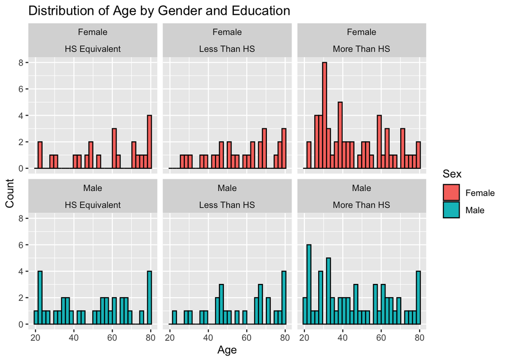

```r
mims_df_clean %>%
  group_by(sex, education) %>%
  ggplot(aes(x = age, fill = sex)) +
  geom_histogram(color = "black") +
  facet_wrap(sex ~ education) +
  labs(
    title = "Distribution of Age by Gender and Education",
    fill = "Sex",
    x = "Age",
    y = "Count"
  )
```

In this plot, we can see that the distribution of age by sex seems to be approximately equal, though there appears to be an especially large concentration of younger women (between 21 and 40 years old) who have completed more than a high school education. The age distributions of those who have not completed high school or completed a high school equivalent, on the other hand, look relatively uniform regardless of gender, and generally have a larger concentration of older participants than the group who has completed more than high school.

#### Plot of Activity Based on Age, across Sex and Education

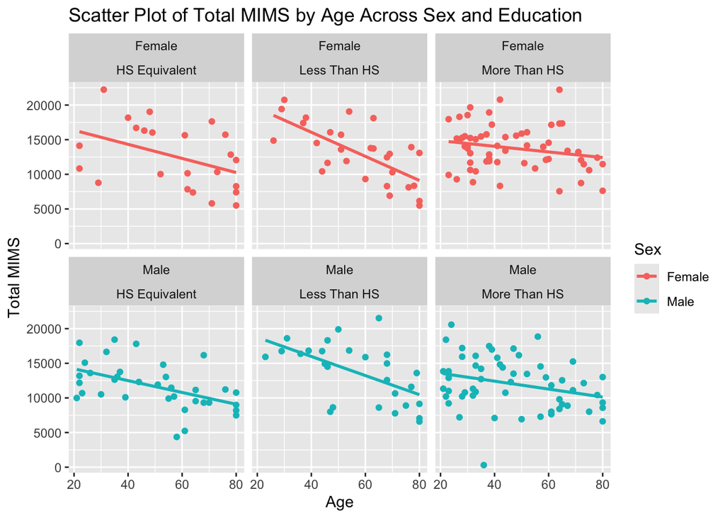

```r
mims_df_clean %>%
  mutate(total_mims = rowSums(across(c(min1:min1440)))) %>%
  ggplot(aes(x = age, y = total_mims, color = sex)) +
  geom_point() +
  geom_smooth(method = "lm", se = FALSE) +
  facet_wrap(sex ~ education) +
  labs(
    title = "Scatter Plot of Total MIMS by Age Across Sex and Education",
    color = "Sex",
    x = "Age",
    y = "Total MIMS"
  )
```

From the plot, we can see that the correlation between total MIMS and age looks to be negative, regardless of sex and education. The association between age and total MIMS looks to be weaker for both men and women with a higher level of education, with the “less than HS” group having the strongest association and the “more than HS” group having the weakest association. Finally, the average total MIMS does not seem to be significantly different among women and men.

#### Activity Plot over the Course of the Day

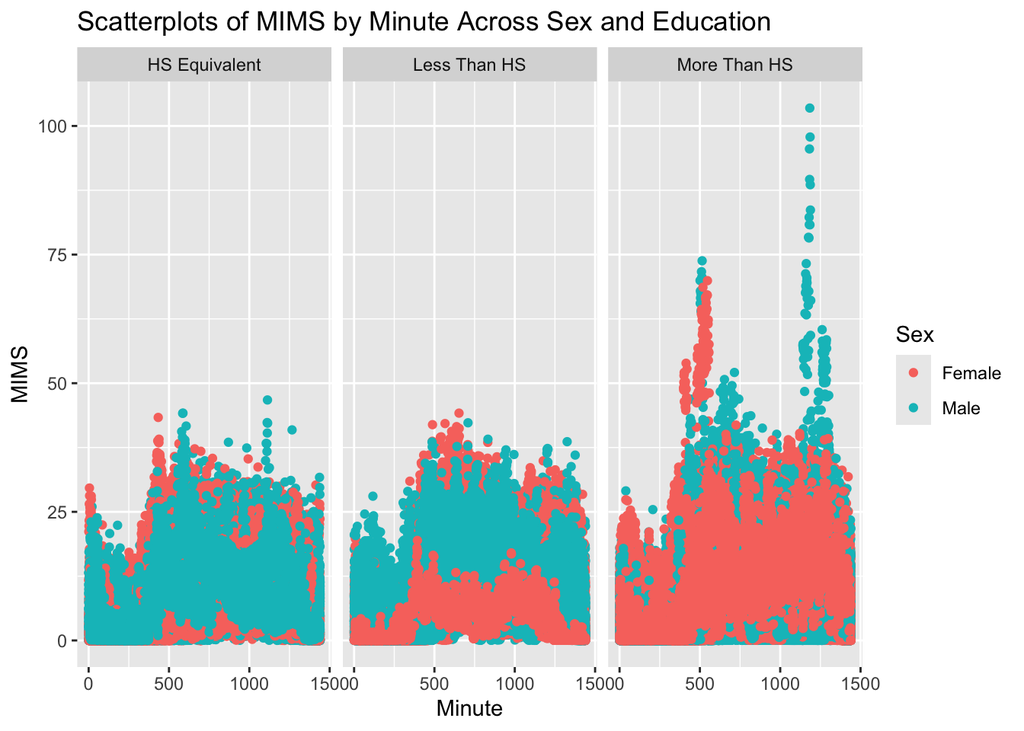

```r
mims_df_clean %>%
  pivot_longer(
    cols = min1:min1440,
    names_to = "minute",
    values_to = "MIMS",
    names_prefix = "min"
  ) %>%
  mutate(minute = as.numeric(minute)) %>%
  ggplot(aes(x = minute, y = MIMS, color = sex)) +
    geom_point() +
    facet_wrap(. ~ education) +
  labs(
    title = "Scatterplots of MIMS by Minute Across Sex and Education",
    x = "Minute",
    color = "Sex"
  )
```

In order to create this plot, I created two new variables called `minute` and `MIMS` so that MIMS can be plotted as a function of the minute of the day.

For all three groups, MIMS activity looks to be low towards the far left end of the graph, which makes sense given that “minute 0” represents midnight, and so the subsequent hours would be in the middle of the night. As the day goes on, the total MIMS generally increases. One interesting trend is that among the “more than HS” group, the peak for women appears to be much earlier than the peak for men, and both peaks are well above those for the “less than HS” and “HS Equivalent” groups.

## Problem 3

#### Import, Tidy, Combine the Data

```r
citi_jan_2020 = read_csv("data/Jan 2020 Citi.csv") %>%
  janitor::clean_names() %>%
  mutate(time = "Jan_2020")
citi_jul_2020 = read_csv("data/July 2020 Citi.csv") %>%
  janitor::clean_names() %>%
  mutate(time = "Jul_2020")
citi_jan_2024 = read_csv("data/Jan 2024 Citi.csv") %>%
  janitor::clean_names() %>%
  mutate(time = "Jan_2024")
citi_jul_2024 = read_csv("data/July 2024 Citi.csv") %>%
  janitor::clean_names() %>%
  mutate(time = "Jul_2024")
citi_df = bind_rows(citi_jan_2020,
                citi_jul_2020,
                citi_jan_2024,
                citi_jul_2024)

citi_jul_2024
```

```
## # A tibble: 47,156 × 8
##    ride_id   rideable_type weekdays duration start_station_name end_station_name
##    <chr>     <chr>         <chr>       <dbl> <chr>              <chr>
##  1 86AE148E… classic_bike  Sunday      19.7  Picnic Point       Yankee Ferry Te…
##  2 FCF07A30… electric_bike Thursday     7.68 W 54 St & 9 Ave    W 42 St & 8 Ave
##  3 D8397E84… classic_bike  Thursday    24.5  12 Ave & W 40 St   W 84 St & Amste…
##  4 E575690C… electric_bike Tuesday      3.53 Grand St & Haveme… S 4 St & Rodney…
##  5 184AABED… electric_bike Wednesd…    24.1  Broadway & Kent A… Henry St & Degr…
##  6 ACA61A92… classic_bike  Saturday     7.83 E 1 St & 1 Ave     Mercer St & Spr…
##  7 C48F946C… classic_bike  Sunday       4.85 Lenox Ave & W 117… Frederick Dougl…
##  8 F3072F6E… classic_bike  Saturday     4.33 W 53 St & 10 Ave   West End Ave & …
##  9 8A283594… electric_bike Thursday    12.6  W 10 St & Washing… Stanton St & Ch…
## 10 EFFCEE4C… electric_bike Friday      10.6  W 55 St & 6 Ave    Broadway & W 41…
## # ℹ 47,146 more rows
## # ℹ 2 more variables: member_casual <chr>, time <chr>
```

#### Describing the Dataset

In the total dataset, there are approximately 100,000 Citi Bike rides between January 2020, July 2020, January 2024, and July 2024. The time period with the most rides is July 2024 (~47% of rides), which is not surprising, considering that more people generally ride bikes in the summer than the winter and July 2020 was in the middle of the COVID-19 pandemic.

The columns of the dataset describe the ride’s unique ID, the type of bike ridden (classic or electric), the day of the week the ride was on, the duration of the ride (in minutes), the stations where the ride started and ended, and whether the rider was a Citi Bike member or a casual rider.

#### Total Number of Rides / Casual/Member Table

##### Using janitor::tabyl

```r
citi_df %>%
  janitor::tabyl(time, member_casual) %>%
  mutate(pct_member = member / (member + casual) * 100)
```

```
##      time casual member pct_member
##  Jan_2020    984  11436   92.07729
##  Jan_2024   2108  16753   88.82350
##  Jul_2020   5637  15411   73.21836
##  Jul_2024  10894  36262   76.89796
```

##### Alternative: using the summarize() function

```r
citi_df %>%
  group_by(time, member_casual) %>%
  summarize(n_obs = n()) %>%
  pivot_wider(
    names_from = member_casual,
    values_from = n_obs
  )
```

```
## # A tibble: 4 × 3
## # Groups:   time [4]
##   time     casual member
##   <chr>     <int>  <int>
## 1 Jan_2020    984  11436
## 2 Jan_2024   2108  16753
## 3 Jul_2020   5637  15411
## 4 Jul_2024  10894  36262
```

#### Table of 5 most popular starting stations

```r
citi_df %>%
  filter(time == "Jul_2024") %>%
  group_by(start_station_name) %>%
  summarize(n_obs = n()) %>%
  arrange(desc(n_obs)) %>%
  slice(1:5)
```

```
## # A tibble: 5 × 2
##   start_station_name       n_obs
##   <chr>                    <int>
## 1 Pier 61 at Chelsea Piers   163
## 2 University Pl & E 14 St    155
## 3 W 21 St & 6 Ave            152
## 4 West St & Chambers St      150
## 5 W 31 St & 7 Ave            146
```

#### Plot of Day of Week/Month/Year on Median Ride Duration

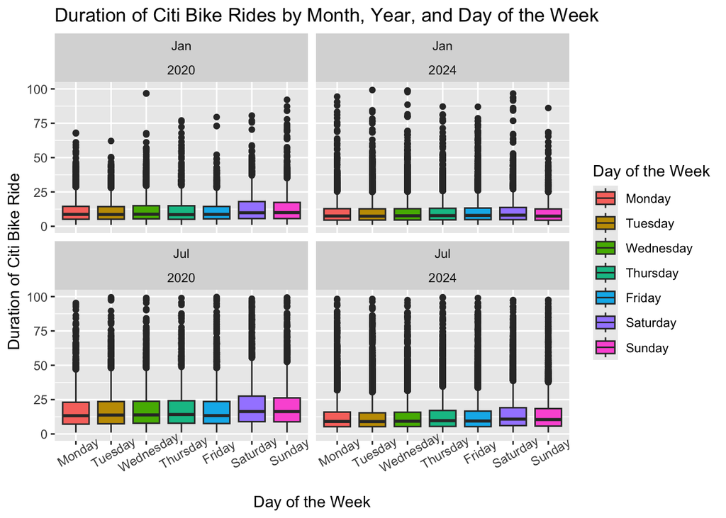

```r
citi_df %>%
  separate_wider_delim(time, names = c("month", "year"), delim = "_") %>%
  mutate(weekday_fac = factor(
    weekdays,
    levels = c("Monday", "Tuesday", "Wednesday", "Thursday",
               "Friday", "Saturday", "Sunday"))) %>%
  ggplot(aes(y = duration, x = weekday_fac, fill = weekday_fac)) +
  geom_boxplot() +
  scale_y_continuous(limits = c(0, 100)) +
  facet_wrap(month ~ year) +
  labs(
    x = "Day of the Week",
    y = "Duration of Citi Bike Ride",
    title = "Duration of Citi Bike Rides by Month, Year, and Day of the Week",
    fill = "Day of the Week"
  ) +
  theme(axis.text.x = element_text(angle = 30))
```

I decided to use side-by-side boxplots to display the median duration, since the “stripe” in the middle of a boxplot represents the median of the distribution. I reordered the `weekday` variable into a factor in order to show the distributions from Monday through Sunday in the correct order.

#### Plot of Month, Membership Status, and Bike Type on Ride Duration

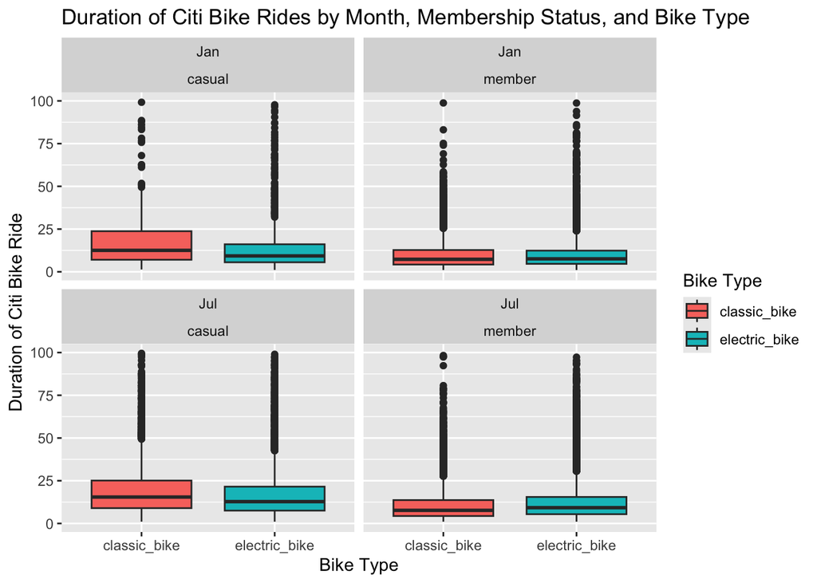

```r
citi_df %>%
  separate_wider_delim(time, names = c("month", "year"), delim = "_") %>%
  filter(year == "2024") %>%
  ggplot(aes(x = rideable_type, y = duration, fill = rideable_type)) +
  geom_boxplot() +
  scale_y_continuous(limits = c(0, 100)) +
  facet_wrap(month ~ member_casual) +
  labs(
    x = "Bike Type",
    y = "Duration of Citi Bike Ride",
    title = "Duration of Citi Bike Rides by Month, Membership Status, and Bike Type",
    fill = "Bike Type"
  )
```